# Building an AI for Starcraft II

In this notebook, I will present a solution for building an AI for the game Starcraft II, which can be found at https://github.com/Ashargin/SC2AI.

Starcraft II is a real-time strategy game . There are three different races : Terrans, Protoss and Zergs. Terrans are a versatile humanoid race with great defensive capabilities. Protoss come with powerful but expensive units. Zergs are an insectoid race which tends to bring weaker but numerous units.

I will try to develop an agent for the Zerg race.

This project includes a lot of code, so for clarity's sake, it will not be written here. Only some simple parts of code will be shown. This notebook will focus on **explaining rather than demonstrating every little detail in the code**, how this works. Anyone interested can still find the code in the Github repository.

## I - pysc2

For this project, I used the pysc2 librairy (https://github.com/deepmind/pysc2) developped by Deepmind. It makes available an environment for Starcraft II that the agent can interact with.

This library is not much documented, or even not documented at all concerning a lot of very important topics (possible actions, observation structure, units attributes, configuration of the agent's interface, etc). The documentation can be found here : https://github.com/deepmind/pysc2/tree/master/docs, but lacks a lot of information.

Therefore, it was necessary to study the code of pysc2 in-depth in order to understand precisely the underlying mechanics, which took a significant part of the project's time.

Here is a summary of what I understood about pysc2 :

- we need to implement a "step" method for our agent, which takes an observation as an argument, and must return an action.
- the possible actions can be seen here : https://github.com/deepmind/pysc2/blob/master/pysc2/lib/actions.py. There are "feature" and "raw" actions. It is important to inspect them in-depth and see what arguments are needed for the different actions. "Feature" actions will require to select a unit and then do something on the next step, like a human would, while "raw" actions will allow to do that in a single step, only specifying the identifier (tag) of the unit which will have to execute the action.
- there are 2 types of observations and actions : the "feature" type is more similar to the human point of view (we can only see what is on the screen, which means that we have to also move the camera, and we do not have access to some additional information) and the "raw" type (we have access to information on all the map simultaneously, as well as some additional variables such as unique identifiers for the units). I chose the "raw" type for this project.
- the environment (https://github.com/deepmind/pysc2/blob/master/pysc2/env/sc2_env.py) allows us to choose the map, the players, the agent interface and many other settings.
- the agent interface can be found in the features (https://github.com/deepmind/pysc2/blob/master/pysc2/lib/features.py) and is a key component of the environment. It specifies the type of observations and actions ("feature" or "raw") and many important settings concerning the data the agent will or will not have access to.
- the units (https://github.com/deepmind/pysc2/blob/master/pysc2/lib/units.py) are another very important piece of code which details how the units are categorized.
- the features need to be read thoroughly because they are poorly documented and extremely important in order to know what information we can use for our agent, but it would be too hard to list them here because there are a lot of them.
- the buffs (https://github.com/deepmind/pysc2/blob/master/pysc2/lib/buffs.py) and the upgrades (https://github.com/deepmind/pysc2/blob/master/pysc2/lib/buffs.py) are also important, for the same reason.

## II - Framework

Now that it is clearer how pysc2 works and how it is made, we will see how we can build functions that our agent will be able to use.

There are a lot of different features that I added to this framework, so in this notebook I will only be able to cover to most important ones.

First, pysc2 includes a wide variety of actions (564 different "raw" actions), and each action takes arguments such as the tag(s) of the unit(s) that will have to execute the action, or the tag(s) of the unit(s), or the map coordinates, that will be targeted by the action. This means that the action space is extremely large and needs to be simplified. The observation is, too, extremely large as we will see later.

We will build different levels of functions so that we have a clear architecture of functions in which we can navigate while not getting lost.

All the framework is defined in the `raw_base_agent.py` script.

Note that I also started to write a `feature_base_agent.py` script for developing an agent in the "feature" mode (human-like mode) if you are interested.

### II - A) Low-level functions

We start by creating a base class for our agent : `RawAgent` (see https://github.com/Ashargin/SC2AI/blob/master/raw_base_agent.py).

We first define the necessary attributes for our class, and subclass the `step` and `reset` methods of the pysc2 `BaseAgent` class. `reset` will be run at the beginning of every game, and `step` will be run at each time step.

Specifically, in the `step` method of our base class, we update our `Memory` object (this will be explained later) and log the last action taken by the agent so we can easily debug it later if we need to.

Then come the core functions (I will not go into the details since this is not the most interesting part) :

- `get_units_by_type(self, unit_type)` will give us the units of the type we want, by looking into our `Memory`.
- `unit_count_by_type gives(self, unit_type)` us the number of corresponding units.
- `get_bases gives(self)` us our bases (in our case, hatcheries since we play the Zerg race).
- `get_base(self, base_number)` gives us the specific base we ask for (for example, the second one), in chronological order.
- `get_workers(self)`, `get_minerals(self)`, `get_vespenes(self)` return our workers, mineral patches on the map, and vespene geysers on the map.
- in `get_premade_coordinates(self, coordinates)`, we build a set of hard-coded, key locations on the map
- in `get_true_buildable_map(self, action)`, we create a "true" map of the buildable locations for the according action (for example, build a Spawning Pool), which is not accessible by default. This is a key component of the low-level functions, so we will give more details later.

The core functions are used a lot in all the different functions in the framework.

And then come the low-level functions. These are maybe the most important parts of the framework. The low-level functions are the following :

- the build function, `build(self, action, builder=None, how=1, where='random')`. Here we handle the details of building a certain building, specifying the builder (in most cases, the Drone), and the different possible settings.
- the same goes for `train(self, action, trainer, how='random')`,
- `cast(self, action, caster, target=('enemy', None), energy=0, how='random')`,
- `attack(self, attackers, coordinates=None, can_reach_ground=True, can_reach_air=True, where='median', defend=False, defend_up_to=0.5, hunt=False)`,
- `move(self, units_to_move, coordinates='home')`,
- and `wait(self)`

It would be hard to go through the whole code, so I will simply give insights about the most interesting parts.

### II - A) a) The build function

We start by selecting the available builders (that are either idle, or mining resources). In most cases, these will be our Drones (workers) but in the case of nydus canals, it will be the Nydus Network.

Then, we try to find a location for our building. This is the most difficult part. We use the `get_true_buildable_map` core function to get a map of the real buildable locations. This is done by :

- using the `pathable`, `buildable`, `player_relative`, `creep` and `visibility_map` features of the minimap features in our observation. We keep the locations that are pathable, buildable, where there are no units, accounting for the creep constraint for Zerg players except if the building is a Hatchery (Zerg players can only build on creep, except for Hatcheries) and the visibility constraint (Creep Tumors can only be built on visible areas of the map). We also add the condition that the building should not be too close to mineral patches or vespene geysers. This is done by using the erode morphological transformation (https://opencv-python-tutroals.readthedocs.io/en/latest/py_tutorials/py_imgproc/py_morphological_ops/py_morphological_ops.html) on the according areas of the map.
- then, we also know that our building has a certain diameter and that the whole building has to be on our buildable map. Thus, we create the map of the buildable locations **for the center of the building** by applying another erosion to the map for the corresponding diameter. The diameter depends on the building, this is why the actions needs to be specified.

Here is an example of a buildable map, and the corresponding minimap at that time, for a hatchery (which has no creep constraint), and then for another building, here a Spore Crawler, which has a creep constraint :

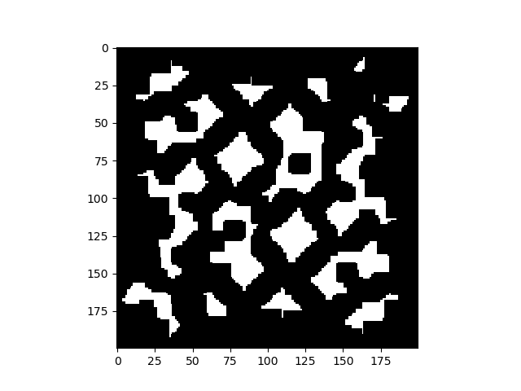

[figure not shown]

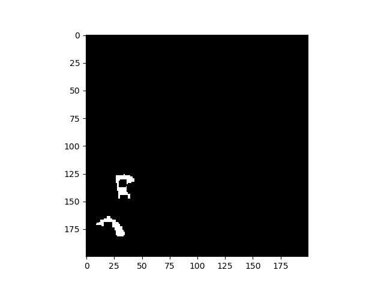

[figure not shown]

We can see that the maps indeed correspond to the buildable areas of the map.

Then, for most buildings, we will simply select the buildable location that is closest to the base we want to build near (this is the `how` parameter).

For hatcheries though, we need to proceed elseway. We implement a simple shortest path algorithm on the feature pathable map in order to know the distances "by foot" and then select the mineral patches which is closest to our bases (according to our shortest path distances), but not too close (or it means we already have a base near it). Then we pick a buildable location which is close to that mineral patch. We select the other mineral patches near this one and once again compute the shortest path algorithm to each of those minerals in order to build a score for the locations, then select the location with the most score.

Then, we select a builder.

More details about the procedure can be found in the code if you feel like you are curious.

### II - A) b) The cast function

The cast function works in a similar way for the Creep Tumors, except it has to deal with the energy of the casters (in the case of Creep Tumors, Queens or Creep Tumors (Creep Tumors can be built by a Queen or another Creep Tumor)).

The procedure is slightly different. We start by selecting a caster, then select the target accordingly if the skill if not a Creep Tumor. If it is a Creep Tumor though, we have to compute the `get_true_buildable_map` again with a visibility constraint, then choose the best location near the caster that is buildable. To choose the "best" location, we create a score such as a location is best if it is far from our base and close to the opponent, and even better if it is close to our current creep border in order to encourage more creep to be spread. We also discourage a Creep Tumor to be built near another Creep Tumor.

As you can see, with this procedure, the creep is spready very fast. Here is an example after some time (the creep is the purple background on the minimap) :

[figure not shown]

The creep is a vital resource for Zerg players because the movement speed of all Zerg units is increased on creep, and more importantly it gives vision, so this is a way to always know what the opponent is sending us.

The `train` function is similar, except simpler since we do not need to look for a location but only for a trainer.

### II - A) c) The attack function

The `attack` function is one of the most complicated. Roughly, the idea is that :

- we choose a "marker point" that is representative of our army. Several settings are possible : 'median' (the median position of our army), 'head' (the position of our army that is farthest from us) or 'tail' (the position of our army that is closest from us).
- we look for enemies (in our `Memory`) that are close to our marker point (and visible). If there are some, we choose a target according to our `ATTACK_PRIORITY` (see https://github.com/Ashargin/SC2AI/blob/master/settings.py). For example, a SiegeTankSieged will be prioritzed over a Marine. There are separate priorities to manage attackers that can reach only air units, only ground units, or both.
- if there are no visible units near, we head to the enemy base.
- we add different functionalities to `defend` or `hunt` if we need to. Defend means that we will only attack units that are not too far from our base, but without any distance restriction from our army. Hunt means that we will try to look for unseen, or previously seen, enemies and structures on the map if there are no visible targets near. This is used to finish the opponent once the game has been mostly won, since we absolutely have to destroy all the enemy structures.

The `move` function is similar.

## II - B) Middle-level functions and the ZergAgent

We create a `ZergAgent` subclass of our `RawAgent` base class. It specifies several things that are specific to the Zerg race such as the `get_harvest_state`, `unit_count_agg`, `get_units_agg`, `get_army` and `check_requirements` core funtions, and contains the middle-level functions.

The middle-level functions are all the more aggregated functions that will make use of the low-level functions. All the train functions (`train_zergling`, `train_hydralisk`, etc..) will use the `train` low-level function, and the same goes for buildings and skill casts with the `build` and `cast` functions. The technological researches are considered as training since the signature is the same.

We implement the functions `train_check_conditions`, `build_check_conditions` and `cast_check_conditions`, that are fundamental because they will :

- check for requirements (for example, a Zergling cannot be trained if no Spawning Pool is built) and return the according requirements **instead** of the desired action if no action has been taken yet to fulfill these requirements. This is done through the `check_requirements` core function. If the requirement is not met yet but an action has already been taken (for example, the Spawning Pool is being built), the function will simply return None, which is very different from self.wait() : None means that the agent will keep looking for another action to be taken at that time step, whereas self.wait() tells that it should wait and not look for another action. This "None principle" is kept throughout all the agent code and is extremely important because it enables **action priority** : try to do that action, and if it returns None, look for the next action on the priority list, etc.
- check if we have enough minerals, vespene, supply, and that we have available trainers / builders / casters and return the desired action if this is the case.
- return self.train_overlord() if we need more supply
- return self.adjust_workers_distribution_intra() if we need minerals or vespene. This will ensure that our workers are properly distributed among mineral patches and extractors.

In other words, the **requirements** but also the **overlords (for supply) and workers distribution** are checked and **the action are automatically taken** so we do not have to explicitely ask for an Overlord, or for a Spawning Pool, or for the workers to be moved between minerals and vespene, if we do not want to. This allows for a great simplification of the orders.

Once again, you are free to look for the code of the function `train_check_requirements` in the script raw_base_agent.py but it may be too big to be shown here, that is why a qualitative explanation is probably clearer.

As an example, here are some middle-level functions. As you can see, the complexity of the code is greatly reduced once the other functions that we described have been defined :

```python
def train_queen(self, how='random'):
    return self.train_check_conditions(RAW_FUNCTIONS.Train_Queen_quick,
            trainer=[units.Zerg.Hatchery, units.Zerg.Lair, units.Zerg.Hive],
            requirements=['SpawningPool', 'Hatchery'],
            minerals=150, supply=2, how=how)

def build_greater_spire(self, how=1):
    return self.train_check_conditions(RAW_FUNCTIONS.Morph_GreaterSpire_quick,
            trainer=units.Zerg.Spire,
            requirements=['Spire', 'Hive'],
            minerals=100, vespene=150, how=how)

def research_melee_attack_2(self, how='random'):
    return self.train_check_conditions(RAW_FUNCTIONS.Research_ZergMeleeWeaponsLevel2_quick,
            trainer=units.Zerg.EvolutionChamber,
            requirements=['EvolutionChamber', 'MeleeAttack1', 'Lair'],
            minerals=150, vespene=150, how=how)
```

We implement in the same way all the train functions for all units and all tech researches, the build functions for all buildings, and the Creep Tumors cast functions.

We also add some more middle-level functions :

- the function to cast Inject Larva, one of the fundamental mechanics of the Zerg race (queens have to inject larvae in the hatcheries so that more units can hatch, since Zerg units not only require resources but also available larvae). Roughly, the idea is that when a base does not have any larva hatching and is not currently calling for a Queen, it "calls" for the closest Queen which has enough energy to cast the skill and asks it to come inject larvae. That way, larvae are continuously hatched in each base in a very efficient manner. We can see that one Queen ends up staying near the base for each of the bases, like most human players do.
- the functions to move workers to minerals, and move workers to gas, if we need more mineral income or more gas income.
- the `adjust_workers_intra` and `adjust_workers_inter functions`. These use the functions above and make sure that the "intra (among one specific base) and "inter" (between the different bases) worker distributions are properly set.
- some rally point functions, to set the rally points of workers and units
- some scout functions, to scout the enemy (there are two functions, one to scout with an overlord which is a very common strategy among human players, and one to scout with zerglings, which is also very commonly done).

**The important thing is :** all these middle-level functions only need arguments specifying some different settings, but all the arguments needed for the pysc2 actions are computed in the low-level functions. This means that we can call `self.build_spawning_pool()` to effectively build a spawning pool without worrying exactly where it will be built, by who, if we can even do it, what we need to do first if we cannot do it yet... The goal is to create a middle-level function for any kind of action that we may want to perform. The low-level functions will then connect these to the pysc2 actions.

**Now the hardest part is done, and we can return actions in a much simpler way.**

## II - C) High-level functions

In this last part of the framework, we will explain how the high-level functions behave.

All the high-level functions call the `main_hl` function, which is responsible of the following :

- checking if an action has already been selected for this time step (if `self.action is not None`). If this is the case, then the function is skipped because we already chose the action that we wanted to pick. There are some exceptions to overwrite the previously selected action though, through the `bypass` variable, but I will not go further into the details.
- if no action has yet been taken, then the desired condition (what we want to achieve) is checked. If it is already fulfilled, then the function is skipped.
- if it is not fulfilled, we see if the population requirement is met (say, we only want to achieve our goal once we have 70 supply first ; this may seem odd to someone unfamiliar with the game, but this is a very common way of looking at build orders : reach a given population, then achieve a goal, then reach another given population and look for the next goal, etc) :
  - if the population requirement is met, the desired action is returned. Note that the desired action is a middle-level action and may itself return an action which is relative to its requirements, or supply conditions, etc, as we have seen earlier.
  - if we need more population first, then we return `increase()`, where `increase` is an argument to the function. Most of the time, it will be `self.train_drone`, meaning that we want to train drones until we have reached the desired population. More complex `increase` functions can be fed, as it is the case in the `MacroZerg` agent class.
- there are additional arguments and settings that you can find in the code if you wish to know the details.

This is what enables the **action priority** that we mentioned earlier : we can write a succession of actions and then the agent will go through all the successive choices as long as it does not pick an action. A reason for keeping to look for an action (when the action is `None`) can be that we do not have any larvae (we absolutely do not want to wait for a larva ; it may take a while, and we want to perform other actions in the meantime), because no trainer / builder / caster has been found (here we do not want to wait either, we want to perform other useful actions as long as this action is not yet available), etc.

Same as the middle-level functions, once the `main_hl` function (and all the other functions above) have been defined, we can define high-level functions in a simple and concise way.

Here are examples of high-level functions :

```python
def train_brood_lord_hl(self, n, pop=0, increase=None, how='random', hard=False):
    action = lambda : self.train_brood_lord(n=n-self.unit_count_agg('BroodLord'), how=how)
    name = 'BroodLord'
    self.main_hl(action, name, n=n, pop=pop, increase=increase, hard=hard)

def research_metabolic_boost_hl(self, pop=0, increase=None, how='random', hard=False):
    action = lambda : self.research_metabolic_boost(how=how)
    name = 'MetabolicBoost'
    self.main_hl(action, name, n=1, pop=pop, increase=increase, hard=hard)

def build_infestation_pit_hl(self, n=1, pop=0, increase=None, how=1, where='random', hard=False):
    action = lambda : self.build_infestation_pit(how=how, where=where)
    name = 'InfestationPit'
    self.main_hl(action, name, n=n, pop=pop, increase=increase, hard=hard)

def adjust_workers_distribution_inter_hl(self, how='equal', timeout=0):
    action = lambda : self.adjust_workers_distribution_inter(how=how, timeout=timeout)
    self.main_hl(action, bypass=True)

def defend_hl(self, pop=0, increase=None, **kwargs):
    action = lambda : self.defend(**kwargs)
    self.main_hl(action, pop=pop, increase=increase, bypass=True)
```

And **this is it** ! Now we can start building an agent, with code as simple as :

For example, if want to build a spawning pool as soon as possible (ie, at population 12, at the start of the game), then 6 zerglings once our population reaches 14, and that we also want to build a second hatchery as soon as possible :

```python
self.build_spawning_pool_hl()
self.train_zergling_hl(6, pop=14)
self.build_hatchery_hl(2)
```

This code will :

- wait for 200 minerals and build a Spawning Pool (as we said, wait is very different from None).
- reach 14 population (training drones, by default, but this can be changed).
- train 6 zerglings
- build a second base. Note that the second base may be built before the 6 zerglings ! This is because of the action priority ; if we do not have 6 zerglings but do not have any larva available, we will not wait for another larva : the action will return None and we will keep looking for an action, which may be the action to build a Hatchery if we have the necessary 300 minerals.

This allows us to build an agent in a very clear and simple way, only defining our build order as above. All the underlying necessary actions, including priorities, will be computed and taken by the `main_hl`, middle-level and low-level functions.

# III - The Memory

We have talked about the `Memory` object before, without really explaining what it was.

The Memory object aims at remembering everything that the agent sees. This is necessary because pysc2 only allows us to look at the current observation but not the past observations. Having a memory of the past observations is absolutely necessary if we do not want to forget what units the enemy has, and even what units we have, since **even our own units can disappear from the observation sometime**, for example when drones are morphing into a building or when they are mining vespene inside a geyser.

The Memory is defined in the `memory.py` script.

Each agent has an attached `Memory` object, and will update it at the beginning of every time step.

The agent's memory contains everything that it needs to know :

- `self_units`, `enemy_units` and `neutral__units` : this is the biggest part of the memory. It contains all our units, all enemy units and all neutral units that we see or have previously seen.
- `birth_dates` : the time step each of the units appeared in our vision. This is useful for defining a chronological order.
- `base_locations` : the locations of our bases, **in chronological order** (the data in the pysc2 observations is not ordered)
- more variables like `has_rally_point`, `spell_targets`, `expired_tumors`, `scouts`, `scout_timeout`, `creep_tumor_tries`, `function_timeout` are needed to track several things that the agent needs to know in order to have its functions run properly, so that actions do not repeat (if a Queen if running towards a base to Inject Larva, we will not make another run to it ; if an Overlord is heading to scout the enemy, we will not send another one ; if the enemy has been scouted recently, we will not do it again, etc).

We will now look at how the memory updates.

First, the `timeout` values are decremented and removed once they reach 0. The idea is that if we only want to perform an action (eg `scout_overlord` or `move_workers_to_gas` for example) once every `timeout` game steps, we associate a `timeout` to the function and forbid the function from being called as long as the `timeout` exists.

More importantly, the biggest part of the `Memory` object is how units are updated : For each of the `self_units`, `enemy_units`, and `neutral_units`:

- we consider our current memory (`old`) and our new observation (`new`).
- we know the tags of the units, so for every unit that we currently see, we replace (or add, if we do not know this unit yet) our current data with the new unit data
- the problem arises for units in our memory that we do not currently see. We need to decide if the unit is dead or not.
  - if it is dead, we remove it from our memory
  - if it is still alive, but we simply do not see it, then we keep it and update some of its attributes : `display_type` (we set its type to `UNSEEN` meaning that we do not see it anymore), `time_unseen` and `time_alive` (these are attributes that do not belong to the pysc2 observation but which I added).
  - it is not obvious how to know if a unit is dead. Fortunately, after searching for a long time, there is a pysc2 setting allowing us to get the **whole native Blizzard Starcraft II observation**, and somewhere in there is the list of dead units that the player saw dying. This ensures that there is no cheating.
  - however, it also brings a problem : there must be units dying somewhere that we cannot see. This is the case of Drones, that technically die, as well as all temporary units (AdeptPhased, MULE...) and, most importantly, morphable units like Barracks, Roaches, etc. The unit will transform into another one and we will not see it dying, meaning that our memory will contain units that actually do not exist anymore, but we cannot know that (imagine that the enemy morphs a Roach into a Ravager and you see the Ravager, you will maybe guess that the Roach does not exist anymore, but you cannot be sure, which means that **both** will be contained in your memory). Unfortunately, this is unavoidable and must be dealt with by the agent.

It is very important to properly define the `Memory` because it will be used in the core functions of the agent, which means that it absolutely have to be accurate. Fortunately, even if there is the "hallucination" problem that we talk about (remember units that do not exist anymore), the problem is minor and the `Memory` is still very accurate.

# IV - Defining our agents

We have everything we need to define our agents in a simple manner now ! Let's dive in.

The agents are written inside the `raw_agents.py` script.

## IV - A) ZerglingRush

The first idea was to build a very simple agent. The most simple kind of agent are agents that do not have many things to do and to think about, that is, agents that are very aggressive as soon as the game starts.

This kind of agents only build the few things it needs, and attacks the opponent. It is simple but can be very effective. These builds are known by RTS players as "Cheese" builds.

The code for the ZerglingRush agent is very simple :

```python
import numpy as np
from pysc2.lib import actions, features, buffs, units
from raw_base_agent import ZergAgent


class ZerglingRush(ZergAgent):
    """Build : https://lotv.spawningtool.com/build/119713/"""

    def __init__(self):
        super().__init__()
        self.mode = 'build'
        self.zerglings_to_push = 12
        self.attack_ended = False

    def reset(self):
        super().reset()
        self.mode = 'build'
        self.attack_ended = False

    def update_mode(self):

        zerglings = [u for u in self.get_units_agg('Zergling')
                       if np.abs(np.array(self.enemy_coordinates) - (u.x, u.y)).sum()
                       <= np.abs(np.array(self.self_coordinates) - (u.x, u.y)).sum()]

        if self.mode == 'build' and len(zerglings) >= 2 + self.zerglings_to_push:
            self.mode = 'attack'
        if self.mode == 'attack' and len(zerglings) <= int((2 + self.zerglings_to_push) / 2):
            self.mode = 'build'

    def attack_then_hunt(self, unit_names='all', can_reach_ground=True, can_reach_air=True):
        if self.attack_ended:
            self.hunt_hl(can_reach_ground=can_reach_ground, can_reach_air=can_reach_air,
                                                unit_names=unit_names, where='median')
        else:
            self.attack_hl(can_reach_ground=can_reach_ground, can_reach_air=can_reach_air,
                                                unit_names=unit_names, where='head')
            if self.action is None or self.action.function == actions.RAW_FUNCTIONS.no_op.id:
                self.attack_ended = True

    def step(self, obs):
        super().step(obs)

        self.update_mode()

        # Build order
        # Always needed
        self.scout_overlord_hl(coordinates='enemy_close', timeout=np.inf)
        self.cast_inject_larva_hl()
        self.set_rally_point_units_hl(coordinates='proxy')

        # Building mode
        if self.mode == 'build':
            self.build_spawning_pool_hl()
            self.train_zergling_hl(6, pop=14)
            self.build_hatchery_hl(2)
            self.train_zergling_hl(10)
            self.train_queen_hl(1)
            self.build_spine_crawler_hl(1, pop=22, increase=self.train_zergling)
            self.train_zergling_hl(np.inf)
            # Move troops back if the attack is canceled:
            self.move_hl(coordinates='proxy')

        # Attack mode
        elif self.mode == 'attack':
            self.train_zergling_hl(np.inf)
            self.attack_then_hunt()

        self.wait_hl()

        return self.action
```

The ZerglingRush agent switches between 2 modes, "build" and "attack". In "build mode", it builds what it needs : a Spawning Pool, a second Hatchery, a Queen, and Zerglings. It even adds a Spine Crawler (this is a static defense turret) for safety, in case the opponent decides to give up defense and attack too.

In "attack" mode, it simply attacks the opponent and hunts him once the attack succeeded to destroy the remaining structure, while keeping training Zerglings.

Also, it always looks if it needs to Inject Larva, and takes care of scouting and setting rally points.

It switches to "attack" mode once it has enough Zerglings", and switches back to "build" mode to retreat if it does not have enough Zerglings, typically if the attack failed. This agent can win even if the first attack was not enough and it had to retreat : the second attack is typically lethal to the opponent.

## IV - B) MacroZerg

Now comes a more interesting kind of agent, an agent that really tries to expand on the whole map, managing many things at once, building a lot of things, harvesting a lot of resources while defending itself to stay alive and eventually destroy the opponent once it gets strong enough.

The code for this agent is more complicated but still really understandable thanks to all the functions we defined in the framework :

```python
class MacroZerg(ZergAgent):
    """Inspired from pro player games"""

    def __init__(self):
        super().__init__()
        self.finished_opening = False
        self.finished_followup = False
        self.finished_midgame = False
        self.midgame_increase = None
        self.attack_ended = False

    def reset(self):
        super().reset()
        self.finished_opening = False
        self.finished_followup = False
        self.finished_midgame = False
        self.midgame_increase = None
        self.attack_ended = False

    def essentials(self):
        self.cast_inject_larva_hl()
        self.move_workers_to_gas_hl(timeout=150)
        self.adjust_workers_distribution_intra_hl(timeout=150)
        self.adjust_workers_distribution_inter_hl(timeout=150)
        self.set_rally_point_units_hl(coordinates='home')
        self.scout_overlord_hl(coordinates='enemy_close', timeout=3000)
        if self.game_step % 10 == 0:
            self.defend_hl(defend_up_to=0.4, with_queen=False)
        self.build_creep_tumor_queen_hl(10)
        self.build_creep_tumor_tumor_hl()

        pop = self.obs.observation.player.food_used
        cap = self.obs.observation.player.food_cap
        if cap >= 66 and pop >= cap - 10 and cap < 200:
            self.train_overlord_hl(self.unit_count_agg('Overlord', with_training=False) + 2)

    def opening(self):
        if self.finished_opening:
            return

        self.train_overlord_hl(2, pop=13)
        self.build_hatchery_hl(2, pop=16)
        self.build_extractor_hl(1, how=1, pop=18)
        self.build_spawning_pool_hl(pop=17)
        self.train_overlord_hl(3, pop=20)
        self.train_queen_hl(2, pop=20)
        self.train_zergling_hl(4, pop=20)
        self.research_metabolic_boost_hl(pop=26)
        self.build_hatchery_hl(3, pop=30)
        self.train_queen_hl(3, pop=30)
        self.train_overlord_hl(4, pop=32)
        self.research_pneumatized_carapace_hl(pop=36)

        if self.obs.observation.player.food_used >= 36 and self.action is None:
            self.finished_opening = True

    def followup_standard(self):
        if self.finished_followup:
            return

        self.train_zergling_hl(6, pop=35)
        self.train_overlord_hl(5, pop=35)
        self.train_queen_hl(4, pop=39)
        self.train_zergling_hl(8, pop=43)
        self.build_spore_crawler_hl(1, how=2, pop=43)
        self.train_overlord_hl(6, pop=43)
        self.train_zergling_hl(10, pop=43)
        self.train_queen_hl(5, pop=48)
        self.train_zergling_hl(12, pop=51)
        self.build_spore_crawler_hl(2, how=1, pop=57)
        self.build_lair_hl(pop=61)

        if self.obs.observation.player.food_used >= 61 and self.action is None:
            self.finished_followup = True

    def followup_eco(self):
        if self.finished_followup:
            return

        self.build_spore_crawler_hl(1, how=2, pop=30)
        self.train_overlord_hl(5, pop=40)
        self.train_queen_hl(4, pop=42)
        self.train_overlord_hl(6, pop=49)
        self.train_queen_hl(5, pop=56)
        self.build_lair_hl(pop=58)

        if self.obs.observation.player.food_used >= 58 and self.action is None:
            self.finished_followup = True

    def midgame_roach_hydralisk(self):
        def increase():
            if self.unit_count_agg('Drone') < 70:
                return self.train_drone()
            elif self.obs.observation.player.vespene < 150:
                return self.train_zergling()
            self.train_roach_hl(20)
            self.train_hydralisk_hl(np.inf)
            return self.action if self.action is not None else self.wait()

        self.midgame_increase = increase
        if self.finished_midgame:
            return

        self.train_queen_hl(6, pop=58, increase=increase)
        self.build_roach_warren_hl(pop=64, increase=increase)
        self.train_queen_hl(7, pop=64, increase=increase)
        self.build_spore_crawler_hl(1, how=2, pop=73, increase=increase)
        self.build_spore_crawler_hl(2, how=1, pop=73, increase=increase)
        self.build_spore_crawler_hl(3, how=3, pop=73, increase=increase)
        self.build_extractor_hl(2, how=1, pop=76, increase=increase)
        self.build_extractor_hl(3, how=2, pop=76, increase=increase)
        self.train_roach_hl(5, pop=76, increase=increase)
        self.train_overseer_hl(1, pop=76, increase=increase)
        self.build_evolution_chamber_hl(1, pop=85, increase=increase)
        self.build_spore_crawler_hl(4, how=2, pop=91, increase=increase)
        self.build_extractor_hl(4, how=2, pop=85, increase=increase)
        self.build_extractor_hl(5, how=3, pop=92, increase=increase)
        self.research_glial_reconstitution_hl(pop=92, increase=increase)
        self.research_missile_attack_1_hl(pop=92, increase=increase)
        self.build_hatchery_hl(4, pop=92, increase=increase)
        self.build_extractor_hl(6, how=3, pop=92, increase=increase)
        self.build_infestation_pit_hl(pop=96, increase=increase)
        self.build_hydralisk_den_hl(pop=96, increase=increase)
        self.train_roach_hl(10, pop=96, increase=increase)
        self.build_spore_crawler_hl(5, how=1, pop=97, increase=increase)
        self.research_grooved_spines_hl(pop=117, increase=increase)
        self.build_spore_crawler_hl(6, how=3, pop=118, increase=increase)
        self.train_queen_hl(8, pop=118, increase=increase)
        self.build_hive_hl(pop=118, increase=increase)
        self.train_hydralisk_hl(10, pop=118, increase=increase)
        self.build_hatchery_hl(5, pop=129, increase=increase)
        self.build_extractor_hl(8, how=5, pop=129, increase=increase)
        self.research_muscular_augments_hl(pop=153, increase=increase)
        self.research_missile_attack_2_hl(pop=159, increase=increase)
        self.build_hatchery_hl(6, pop=159, increase=increase)
        self.build_extractor_hl(10, how=6, pop=159, increase=increase)
        self.build_evolution_chamber_hl(2, pop=159, increase=increase)
        self.train_overseer_hl(2, pop=158, increase=increase)
        self.research_ground_armor_1_hl(pop=158, increase=increase)

        if self.obs.observation.player.food_used >= 158 and self.action is None:
            self.finished_midgame = True

    def midgame_baneling(self):
        def increase():
            if self.unit_count_agg('Drone') < 70:
                return self.train_drone()
            elif self.obs.observation.player.vespene < 150:
                return self.train_zergling()
            self.train_hydralisk_hl(14)
            self.train_baneling_hl(np.inf)
            return self.action if self.action is not None else self.wait()

        self.midgame_increase = increase
        if self.finished_midgame:
            return

        self.build_baneling_nest_hl(pop=58, increase=increase)
        self.train_queen_hl(6, pop=62, increase=increase)
        self.train_zergling_hl(10, pop=62, increase=increase)
        self.build_extractor_hl(2, how=1, pop=62, increase=increase)
        self.build_extractor_hl(3, how=2, pop=62, increase=increase)
        self.train_zergling_hl(12, pop=72, increase=increase)
        self.build_hatchery_hl(4, pop=77, increase=increase)
        self.build_extractor_hl(4, how=2, pop=62, increase=increase)
        self.build_extractor_hl(5, how=3, pop=62, increase=increase)
        self.train_overseer_hl(1, pop=78, increase=increase)
        self.build_evolution_chamber_hl(2, pop=78, increase=increase)
        self.research_centrifugal_hooks_hl(pop=80, increase=increase)
        self.train_baneling_hl(8, pop=81, increase=increase)
        self.research_melee_attack_1_hl(pop=94, increase=increase)
        self.build_hydralisk_den_hl(pop=94, increase=increase)
        self.build_hatchery_hl(5, pop=93, increase=increase)
        self.train_queen_hl(7, pop=98, increase=increase)
        self.train_baneling_hl(10, pop=105, increase=increase)
        self.research_muscular_augments_hl(pop=109, increase=increase)
        self.build_extractor_hl(6, how=3, pop=109, increase=increase)
        self.build_infestation_pit_hl(pop=109, increase=increase)
        self.research_ground_armor_1_hl(pop=115, increase=increase)
        self.build_hatchery_hl(6, pop=119, increase=increase)
        self.build_hive_hl(pop=118, increase=increase)
        self.train_hydralisk_hl(5, pop=127, increase=increase)
        self.build_extractor_hl(7, how=5, pop=137, increase=increase)
        self.train_hydralisk_hl(10, pop=140, increase=increase)
        self.research_grooved_spines_hl(pop=140, increase=increase)
        self.research_melee_attack_2_hl(pop=147, increase=increase)
        self.build_extractor_hl(8, how=5, pop=150, increase=increase)

        if self.obs.observation.player.food_used >= 150 and self.action is None:
            self.finished_midgame = True

    def lategame_ultralisk_broodlord(self):
        def increase():
            if self.unit_count_agg('UltraliskCavern', with_training=False) == 0 \
                        or self.unit_count_agg('GreaterSpire', with_training=False) == 0:
                return self.midgame_increase()
            elif self.unit_count_agg('Drone') < 70:
                return self.train_drone()
            elif self.obs.observation.player.vespene < 300:
                return self.train_zergling()
            self.train_ultralisk_hl(2)
            self.train_brood_lord_hl(2)
            self.train_corruptor_hl(3)
            self.train_ultralisk_hl(4)
            self.train_brood_lord_hl(4)
            self.train_corruptor_hl(6)
            self.train_ultralisk_hl(6)
            self.train_brood_lord_hl(6)
            self.train_corruptor_hl(9)
            self.train_brood_lord_hl(np.inf)
            return self.action if self.action is not None else self.wait()

        self.build_spire_hl(pop=140, increase=increase)
        self.build_greater_spire_hl(pop=140, increase=increase)
        self.build_ultralisk_cavern_hl(pop=140, increase=increase)
        self.research_chitinous_plating_hl(pop=160, increase=increase)
        self.research_ground_armor_2_hl(pop=160, increase=increase)
        self.research_flyer_attack_1_hl(pop=160, increase=increase)
        self.research_melee_attack_1_hl(pop=160, increase=increase)
        self.build_spire_hl(2, pop=170, increase=increase)
        self.research_flyer_armor_1_hl(pop=170, increase=increase)
        self.research_flyer_attack_2_hl(pop=170, increase=increase)
        self.research_anabolic_synthesis_hl(pop=170, increase=increase)
        self.research_adrenal_glands_hl(pop=180, increase=increase)
        self.research_melee_attack_2_hl(pop=180, increase=increase)
        self.research_flyer_armor_2_hl(pop=180, increase=increase)
        self.research_flyer_attack_3_hl(pop=180, increase=increase)
        self.research_flyer_armor_3_hl(pop=180, increase=increase)
        self.research_melee_attack_3_hl(pop=180, increase=increase)
        self.wait_hl(pop=200, increase=increase)

        if self.obs.observation.player.food_used >= 190:
            if self.game_step % 2 == 0 or self.unit_count_agg('Corruptor', with_training=False) == 0:
                ZerglingRush.attack_then_hunt(self, can_reach_air=False,
                                              unit_names=['Zergling', 'Baneling',
                                                          'Roach', 'Hydralisk',
                                                          'Ultralisk', 'BroodLord'])
            else:
                ZerglingRush.attack_then_hunt(self, can_reach_ground=False,
                                              unit_names=['Corruptor'])

    def step(self, obs):
        super().step(obs)

        # Build order
        # Always needed
        self.essentials()
        self.opening()
        self.followup_standard()
        self.midgame_baneling()
        self.lategame_ultralisk_broodlord()

        self.wait_hl()
        return self.action
```

For this agent, we define essential actions which will always be tried, as well as an opening, a followup, a midgame and a lategame. We added two different followups and two different midgames for more diversity. All these parts of build orders were inspire from pro player games.

The code above uses the `followup_standard` followup and the `midgame_baneling` midgame, but you could switch to `midgame_roach_hydralisk` for example.

The opening is always the same and leads to several possible build orders. The two midgames that we implemented mainly make use either of the Baneling, or of the Roaches and Hydralisks. Then, the agent transitions towards a lategame made of Ultralisk, Corruptors, and Brood Lords, which are the strongest Zerg units available but cannot be trained too early in the game or the agent would become too weak and could easily be defeated by the opponent.

This agent also heavily focuses on researches, especially in the lategame stage.

## IV - C) SmartZerg

The two previous agents were hard-coded, and we now try an agent which learns from Reinforcement Learning. This agent will use the DQN algorithm (deep Q-network, https://towardsdatascience.com/deep-reinforcement-learning-build-a-deep-q-network-dqn-to-play-cartpole-with-tensorflow-2-and-gym-8e105744b998).

This is done with Keras and Tensorflow, but not with RL libraries like the openAI gym, which are uncompatible with the pysc2 environment.

The code for this agent is the following :

```python
import tensorflow as tf
config = tf.compat.v1.ConfigProto()
config.gpu_options.allow_growth=True
sess = tf.compat.v1.Session(config=config)

import random as rd
from keras.models import Sequential
from keras.layers import Dense
from keras.optimizers import Adam
from settings import STEP_MUL

class SmartZerg(ZergAgent):
    def __init__(self, learning_rate=0.001, discount=0.99, batch_size=128, memory_size=1024,
                 epsilon=1.0, epsilon_decay=0.9999, epsilon_min=0.1, episode_length=25000,
                 action_space_mode='full', observation_space_mode='full'):
        super().__init__()
        self.learning_rate = learning_rate
        self.discount = discount
        self.batch_size = batch_size
        self.memory_size = memory_size
        self.epsilon = epsilon
        self.epsilon_decay = epsilon_decay
        self.epsilon_min = epsilon_min
        self.episode_length = episode_length
        self.action_space_mode = action_space_mode
        self.observation_space_mode = observation_space_mode
        self.action_space = self.get_action_space()
        self.net = None
        self.position = 0
        self.previous_state = None
        self.previous_q_values = None
        self.previous_action = None
        self.replay_memory = []
        self.rewards = []
        self.attack_ended = False

    def reset(self):
        super().reset()
        self.position = 0
        self.previous_state = None
        self.previous_q_values = None
        self.previous_action = None
        self.replay_memory = []
        self.rewards.append([])
        self.attack_ended = False

    def get_action_space(self):
        if self.action_space_mode == 'limited':
            return [self.train_drone,
                    self.train_queen,
                    self.train_roach,
                    self.train_zergling,
                    self.train_hydralisk,
                    self.research_missile_attack_2,
                    self.build_hatchery,
                    self.scout_zergling,
                    self.defend,
                    self.wait]

        return [self.train_baneling,
                self.train_brood_lord,
                self.train_corruptor,
                self.train_drone,
                self.train_hydralisk,
                self.train_mutalisk,
                self.train_overlord,
                self.train_overseer,
                self.train_queen,
                self.train_ravager,
                self.train_roach,
                self.train_ultralisk,
                self.train_zergling,
                self.build_creep_tumor_queen,
                self.build_creep_tumor_tumor,
                self.build_evolution_chamber,
                self.build_extractor,
                self.build_hatchery,
                self.build_spine_crawler,
                self.build_spore_crawler,
                self.research_pneumatized_carapace,
                self.research_metabolic_boost,
                self.research_muscular_augments,
                self.research_glial_reconstitution,
                self.research_centrifugal_hooks,
                self.research_grooved_spines,
                self.research_adrenal_glands,
                self.research_chitinous_plating,
                self.research_anabolic_synthesis,
                self.research_melee_attack_3,
                self.research_missile_attack_3,
                self.research_ground_armor_3,
                self.research_flyer_attack_3,
                self.research_flyer_armor_3,
                self.scout_overlord,
                self.scout_zergling,
                self.move,
                self.attack,
                self.hunt,
                self.defend,
                self.wait]

    def build_net(self):
        n_actions = len(self.action_space)
        state_size = len(self.get_state())

        model = Sequential()
        model.add(Dense(200, activation='relu', input_shape=(state_size,)))
        model.add(Dense(200, activation='relu'))
        model.add(Dense(n_actions))

        model.compile(optimizer=Adam(self.learning_rate), loss='mse')

        return model

    def get_state(self):
        if self.observation_space_mode == 'limited':
            # Resources
            state = [self.obs.observation.player.minerals,
                    self.obs.observation.player.vespene,
                    self.obs.observation.player.food_used,
                    self.obs.observation.player.food_cap - self.obs.observation.player.food_used]

            # Self units
                # Unit count
            state += [self.unit_count_agg(unit_name, with_burrowed=False) for unit_name in
                        ['Drone', 'Queen', 'Roach', 'Zergling', 'Hatchery']]
                # Requirements
            state += [(self.unit_count_agg(unit_name, with_burrowed=False, with_training=False) > 0) *  1
                    for unit_name in
                    ['RoachWarren', 'SpawningPool']]
                # Capabilities
            state += [(max([0] + [u.energy for u in self.get_units_agg('Queen', with_burrowed=False)])
                    >= 25) * 1] \
                + [any([u.order_id_0 == actions.RAW_FUNCTIONS.no_op.id
                        for u in self.get_units_agg(unit_name, with_burrowed=False)]) * 1
                    for unit_name in
                    ['Hatchery']]

            # Enemy units
            enemy_counts = [(len(self.memory.enemy_units[unit_type]), s) for unit_type, s in
                            [(units.Protoss.Immortal, 4),
                            (units.Protoss.Zealot, 2),
                            (units.Protoss.Stalker, 2),
                            (units.Protoss.Adept, 2),
                            (units.Protoss.VoidRay, 4),
                            (units.Protoss.Probe, 1)]]
            enemy_counts, enemy_unit_supplies = zip(*enemy_counts)
            state += list(enemy_counts)

            # Macro state
            state += [self.obs.observation.player.food_used - self.unit_count_agg('Drone')] \
                   + [sum([count * s for count, s in zip(enemy_counts, enemy_unit_supplies)])] \
                   + [sum([count * s for count, s in zip(enemy_counts, enemy_unit_supplies)])
                       - len(self.memory.enemy_units[units.Protoss.Probe])
                       - len(self.memory.enemy_units[units.Terran.SCV])
                       - len(self.memory.enemy_units[units.Zerg.Drone])]
```

```python
            # Map features
            enemy_units_map = np.stack([self.obs.observation.feature_minimap.visibility_map
                                        == features.Visibility.VISIBLE,
                                        self.obs.observation.feature_minimap.player_relative
                                        == features.PlayerRelative.ENEMY]).all(axis=0).T.astype('uint8')
            if np.subtract(*self.self_coordinates) > 0:
                enemy_close_map = np.tril(enemy_units_map)
            else:
                enemy_close_map = np.triu(enemy_units_map)
            state += [min(enemy_close_map.sum(), 1)]

            return np.array(state)

        # Resources
        state = [self.obs.observation.player.minerals,
                 self.obs.observation.player.vespene,
                 self.obs.observation.player.food_used,
                 self.obs.observation.player.food_cap - self.obs.observation.player.food_used]

        # Self units
               # Unit count
        state += [self.unit_count_agg(unit_name, with_burrowed=False) for unit_name in
                    ['Baneling', 'BroodLord', 'Corruptor', 'Drone', 'Hydralisk', 'Larva',
                     'Mutalisk', 'Overlord', 'Overseer', 'Queen', 'Ravager', 'Roach', 'Ultralisk',
                     'Zergling', 'BanelingNest', 'CreepTumor', 'EvolutionChamber', 'Extractor',
                     'Hatchery', 'Lair', 'Hive', 'HydraliskDen', 'InfestationPit', 'RoachWarren',
                     'SpawningPool', 'SpineCrawler', 'Spire', 'GreaterSpire', 'SporeCrawler',
                     'UltraliskCavern', 'PneumatizedCarapace', 'MetabolicBoost',
                     'MuscularAugments', 'GlialReconstitution', 'CentrifugalHooks',
                     'GroovedSpines', 'AdrenalGlands', 'ChitinousPlating', 'AnabolicSynthesis']] \
               + [sum([self.unit_count_agg(lvl) for lvl in research_names]) for research_names in
                        [['MeleeAttack1', 'MeleeAttack2', 'MeleeAttack3'],
                         ['MissileAttack1', 'MissileAttack2', 'MissileAttack3'],
                         ['GroundArmor1', 'GroundArmor2', 'GroundArmor3'],
                         ['FlyerAttack1', 'FlyerAttack2', 'FlyerAttack3'],
                         ['FlyerArmor1', 'FlyerArmor2', 'FlyerArmor3']]]
               # Requirements
        state += [(self.unit_count_agg(unit_name, with_burrowed=False, with_training=False) > 0) *  1
                  for unit_name in
                  ['Corruptor', 'Roach', 'Zergling', 'BanelingNest', 'CreepTumor', 'Hatchery',
                   'Lair', 'Hive', 'HydraliskDen', 'InfestationPit', 'RoachWarren', 'SpawningPool',
                   'Spire', 'GreaterSpire', 'UltraliskCavern']]
               # Capabilities
        state += [(max([0] + [u.energy for u in self.get_units_agg('Queen', with_burrowed=False)])
                   >= 25) * 1] \
               + [any([u.order_id_0 == actions.RAW_FUNCTIONS.no_op.id
                       for u in self.get_units_agg(unit_name, with_burrowed=False)]) * 1
                  for unit_name in
                  ['EvolutionChamber', 'Hatchery', 'HydraliskDen', 'Spire', 'UltraliskCavern']]

        # Enemy units
        enemy_counts = [(len(self.memory.enemy_units[unit_type]), s) for unit_type, s in
                        [(units.Protoss.DarkTemplar, 2),
                         (units.Protoss.Archon, 4),
                         (units.Protoss.HighTemplar, 2),
                         (units.Protoss.Disruptor, 3),
                         (units.Protoss.Colossus, 6),
                         (units.Protoss.Immortal, 4),
                         (units.Protoss.Zealot, 2),
                         (units.Protoss.Stalker, 2),
                         (units.Protoss.Adept, 2),
                         (units.Protoss.PhotonCannon, 0),
                         (units.Protoss.Sentry, 2),
                         (units.Protoss.Probe, 1),
                         (units.Protoss.Carrier, 6),
                         (units.Protoss.Mothership, 8),
                         (units.Protoss.VoidRay, 4),
                         (units.Protoss.Tempest, 5),
                         (units.Protoss.WarpPrism, 2),
                         (units.Protoss.Oracle, 3),
                         (units.Protoss.Phoenix, 2),
                         (units.Protoss.Observer, 1),

                         (units.Terran.SiegeTankSieged, 3),
                         (units.Terran.Thor, 6),
                         (units.Terran.Ghost, 2),
                         (units.Terran.VikingAssault, 2),
                         (units.Terran.Hellbat, 2),
                         (units.Terran.Hellion, 2),
                         (units.Terran.Cyclone, 3),
                         (units.Terran.WidowMineBurrowed, 2),
                         (units.Terran.Marauder, 2),
                         (units.Terran.Reaper, 1),
                         (units.Terran.Marine, 1),
                         (units.Terran.Bunker, 0),
                         (units.Terran.SiegeTank, 3),
                         (units.Terran.MissileTurret, 0),
                         (units.Terran.SCV, 1),
                         (units.Terran.Battlecruiser, 6),
                         (units.Terran.Liberator, 3),
                         (units.Terran.Raven, 2),
                         (units.Terran.Banshee, 3),
                         (units.Terran.VikingFighter, 2),
                         (units.Terran.Medivac, 2),

                         (units.Zerg.Lurker, 3),
                         (units.Zerg.Ultralisk, 6),
                         (units.Zerg.Infestor, 2),
                         (units.Zerg.SwarmHost, 3),
                         (units.Zerg.Hydralisk, 2),
                         (units.Zerg.Ravager, 3),
                         (units.Zerg.Roach, 2),
                         (units.Zerg.Queen, 2),
                         (units.Zerg.SpineCrawler, 0),
                         (units.Zerg.SporeCrawler, 0),
                         (units.Zerg.Zergling, 0.5),
                         (units.Zerg.Drone, 1),
                         (units.Zerg.Baneling, 0.5),
                         (units.Zerg.BroodLord, 4),
                         (units.Zerg.Mutalisk, 2),
                         (units.Zerg.Corruptor, 2),
                         (units.Zerg.Viper, 3),
                         (units.Zerg.OverlordTransport, 0),
                         (units.Zerg.Overseer, 0)]]
        enemy_counts, enemy_unit_supplies = zip(*enemy_counts)
        state += list(enemy_counts)
```

```python
        # Macro state
        state += [self.game_step] \
               + [sum([max(b.assigned_harvesters - b.ideal_harvesters, 0) for b in self.get_bases()])] \
               + [sum([max(b.ideal_harvesters - b.assigned_harvesters, 0) for b in self.get_bases()])] \
               + [sum([3 - u.assigned_harvesters for u in self.get_units_agg('Extractor')])] \
               + [any([u.buff_id_0 != buffs.Buffs.QueenSpawnLarvaTimer
                       for u in self.get_units_agg('Hatchery')]) * 1] \
               + [self.obs.observation.player.food_used - self.unit_count_agg('Drone')] \
               + [sum([count * s for count, s in zip(enemy_counts, enemy_unit_supplies)])] \
               + [sum([count * s for count, s in zip(enemy_counts, enemy_unit_supplies)])
                  - len(self.memory.enemy_units[units.Protoss.Probe])
                  - len(self.memory.enemy_units[units.Terran.SCV])
                  - len(self.memory.enemy_units[units.Zerg.Drone])]

        # Map features
        enemy_units_map = np.stack([self.obs.observation.feature_minimap.visibility_map
                                    == features.Visibility.VISIBLE,
                                    self.obs.observation.feature_minimap.player_relative
                                    == features.PlayerRelative.ENEMY]).all(axis=0).T.astype('uint8')
        if np.subtract(*self.self_coordinates) > 0:
            enemy_close_map = np.tril(enemy_units_map)
        else:
            enemy_close_map = np.triu(enemy_units_map)
        state += [np.array(self.obs.observation.feature_minimap.creep.T).sum()
                  / self.obs.observation.feature_minimap.creep.size] \
               + [min(enemy_close_map.sum(), 1)]

        return np.array(state)

    def learn(self, s, q, a, r, q_, is_terminal=False):
        target = q
        target[a] = r + self.discount * max(q_) * (not is_terminal)

        if len(self.replay_memory) < self.memory_size:
            self.replay_memory.append(None)
        self.replay_memory[self.position] = (s, target)
        self.position = (self.position + 1) % self.memory_size

        if len(self.replay_memory) >= self.batch_size:
            batch = rd.sample(self.replay_memory, self.batch_size)
            X, y = zip(*batch)
            self.net.train_on_batch(np.array(X), np.array(y))

    def step(self, obs):
        super().step(obs)

        if self.net is None:
            self.net = self.build_net()

        self.cast_inject_larva_hl()
        self.adjust_workers_distribution_intra_hl(timeout=150)
        self.adjust_workers_distribution_inter_hl(timeout=150)
        pop = self.obs.observation.player.food_used
        cap = self.obs.observation.player.food_cap
        if cap >= 66 and pop >= cap - 10 and cap < 200:
            self.train_overlord_hl(self.unit_count_agg('Overlord', with_training=False) + 2)
        if self.obs.observation.player.food_used >= 190:
            ZerglingRush.attack_then_hunt(self)

        if self.action is not None:
            return self.action

        state = self.get_state()
        q_values = self.net.predict(state.reshape((1, -1))).ravel()
        if np.random.random() > self.epsilon:
            action = np.argmax(q_values)
        else:
            action = np.random.randint(len(self.action_space))
        self.epsilon = max(self.epsilon * self.epsilon_decay, self.epsilon_min)

        if self.previous_action is not None:
            self.learn(self.previous_state,
                       self.previous_q_values,
                       self.previous_action,
                       obs.reward,
                       q_values,
                       is_terminal=self.obs.last()
                                   or self.game_step * STEP_MUL > self.episode_length)

        self.previous_state = state
        self.previous_q_values = q_values
        self.previous_action = action

        self.action = self.action_space[action]()

        self.wait_hl()

        self.rewards[-1].append(self.obs.reward)

        return self.action
```

We have to define an action space and an observation space (see `get_action_space` and `get_state`). The action space is made of middle-level functions from the framework, which makes it a lot easier compared to using pysc2 actions, for the reasons that we already stated.

Then the DQN algorithm is applied : the q-values of the current state are predicted via the deep feedforward neural network, and the action with the highest predicted value is picked. An epsilon parameter to sometimes randomly pick an action regardless of the q-values is added for exploration (this is standard in RL algorithms). Then the algorithms learns from the reward it receives and the state it ends up into.

For more information, read the DQN article : https://towardsdatascience.com/deep-reinforcement-learning-build-a-deep-q-network-dqn-to-play-cartpole-with-tensorflow-2-and-gym-8e105744b998.

We also add some hard-coded behavior to help the agent find the right way to behave.

Last, the agents will run against the Blizzard AI thanks to the code you will find in the `main.py` script below :

```python
import os
import numpy as np
import cProfile
import pickle
from absl import app
from pysc2.env import sc2_env
from pysc2.lib import features
from raw_agents import ZerglingRush, MacroZerg, SmartZerg
from settings import RESOLUTION, STEP_MUL

# Settings
agent = MacroZerg()
op_race = 'terran' # random, terran, protoss, zerg
op_difficulty = 'very_hard' # very_easy, easy, medium, medium_hard, hard, harder, very_hard
op_build = 'macro' # random, rush, timing, power, macro, air
map_name = 'WorldofSleepers'
visualize = True
realtime = False
n_games = 1
save_replay_episodes = 1 # whether to save a replay
time = False
time_iter = 12000

def main(unused_args):
    try:
        for i in range(n_games):
            print(f'Game {i+1}')

            with sc2_env.SC2Env(
                map_name=map_name,
                players=[sc2_env.Agent(getattr(sc2_env.Race, agent.race_name)),
                         sc2_env.Bot(getattr(sc2_env.Race, op_race),
                                     getattr(sc2_env.Difficulty, op_difficulty),
                                     getattr(sc2_env.BotBuild, op_build))],
                agent_interface_format=features.AgentInterfaceFormat(
                    feature_dimensions=features.Dimensions(screen=RESOLUTION, minimap=RESOLUTION),
                    raw_resolution=RESOLUTION,
                    use_feature_units=True,
                    use_raw_units=True,
                    use_raw_actions=agent.raw_interface,
                    show_cloaked=True,
                    show_burrowed_shadows=True,
                    show_placeholders=True,
                    add_cargo_to_units=True,
                    crop_to_playable_area=True,
                    raw_crop_to_playable_area=True,
                    send_observation_proto=True
                    ),
                step_mul=STEP_MUL,
                score_index=features.ScoreCumulative.score,
                visualize=visualize,
                realtime=realtime,
                save_replay_episodes=save_replay_episodes,
                replay_dir='{}\\data\\replays'.format(os.path.abspath(os.getcwd()))
                ) as env:

                agent.setup(env.observation_spec(), env.action_spec())
                timesteps = env.reset()
                agent.reset()
                while True:
                    step_actions = [agent.step(timesteps[0])]
                    if timesteps[0].last() or time and agent.game_step * STEP_MUL > time_iter \
                                            or agent.episode_length is not None \
                                            and agent.game_step * STEP_MUL > agent.episode_length:
                        break
                    timesteps = env.step(step_actions)

            if time:
                break

            if isinstance(agent, SmartZerg):
                agent.net.save(r'data/net.h5')
                rewards = np.array([x for sub in agent.rewards for x in sub])
                np.save(r'data/rewards.npy', rewards)

    except KeyboardInterrupt:
        agent.log.close()

    return agent

if time:
    timed = cProfile.run('app.run(main)')
    print(timed)
elif __name__ == "__main__":
    app.run(main)
```

# V - Results and conclusion

After several optimizations to improve the framework and the agents build orders, **both the ZerglingRush and the MacroZerg manage to beat the Starcraft II AI, in the 3 different races for the opponent (Terran, Protoss and Zerg) and at the highest difficulty available (Elite).**

This is less impressive for the ZerglingRush agent because the opponent seems to defend very poorly against early attacks, but the MacroZerg has shown that it performs really well.

The main advantage of our agents compared to humans is that they almost have no reaction time : every action that needs to be taken, is taken immediatly. The agent ends up a lot ahead from the opponent, simply because everything is performed exactly at the right time, and a huge advantage can be cumulated over time.

The SmartZerg agent, though, can beat the medium difficulty AI (and, still, mainly thanks to its hard-coded components) but cannot beat the hard difficulty agent. It builds a lot of hatcheries, a lot of extractors, trains a lot of queens, without really recognizing the right time to perform those actions.

Even though the SmartZerg agent does not perform very well, we can see that it learns something : here is the reward curve obtained by the agent over 25 games :

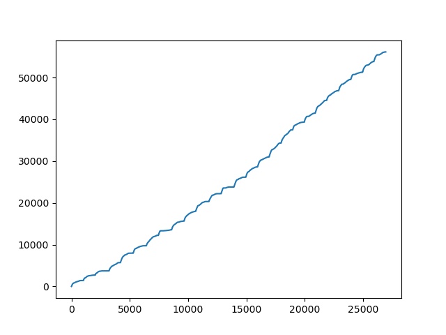

We can see that the curve is (slightly) rising over time.

Last but not least, (commented) **videos of ZerglingRush and MacroZerg against the Blizzard Elite Terran AI are available** on the github repository.

Those should be easy to grasp and more entertaining.

ZerglingRush : download from https://github.com/Ashargin/SC2AI/blob/master/data/replays/ZerglingRush_vs_TerranElite.mp4

MacroZerg : download from https://github.com/Ashargin/SC2AI/blob/master/data/replays/MacroZerg_vs_TerranElite.mp4